# MATH-156 - Week 5 - Concepts in Probability

**Directions**:

- As always, the expectation is that you thoughtfully work through this activity with a partner, discussing the embedded questions and recording your responses in a shared document
  - We will pause every 10ish minutes to go over certain questions as a class, you are expected to revise your write-up to update any responses that are inaccurate based upon these discussions
  - At times you will be asked to add screenshots to your write-up. If you are on a Windows PC, an easy way to do this is the “snipping tool”, which you can find using the search bar along the bottom of your screen. If you are on a Mac, you can find instructions on [how to take a screenshot at this link](https://support.apple.com/en-us/HT201361).
- Both you and your partner should upload your write-up to Canvas after class
  - Depending on our conversations you might not have time to finish all the questions in class - that’s okay and you don’t need to do them on your own. Your grade on these write-ups will be based upon whether you worked diligently during class. Accuracy will only count on one or two key questions (which will not be disclosed ahead of time, but will be early enough that you will have completed them if you were working at an appropriate pace)
- With that said, please do not try and rush through the questions, the purpose of these activities is to learn the material, not to hurriedly complete all the questions

$~$

## Introduction

We began the semester focused on describing the trends in the data we had access to. However, we’ve since learned that a more meaningful analysis will attempt to *generalize* these trends to a broader group of cases.

More specifically, the data we analyze is almost always a *sample*, so there is *uncertainty* in how well our findings will represent the population. Put differently, if we repeated our study (ie: collected another sample or re-did our random assignment) we’d expect to see slightly different results. Probability provides statisticians with a tool for determining whether this uncertainty is enough to sway the conclusions we draw.

$~$

## Probability Rules

I’ll admit that the next few sections are somewhat far from actual scientific research, but they will help us begin to connect the probability rules introduced in this week’s lectures with the uncertainty that exists in real data.

### Warm-up

Drawing from a deck of cards is a classic example used to teach probability rules. Shown below is a diagram of the 52 cards in a standard deck:

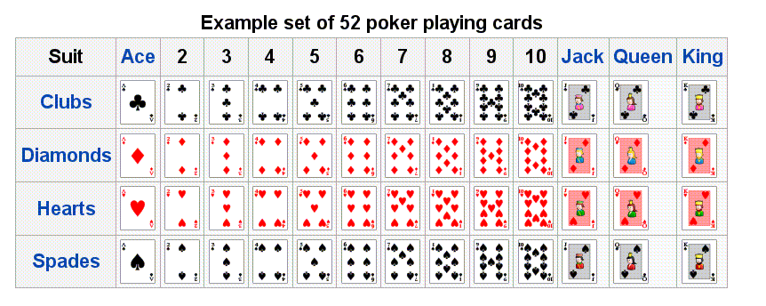

**Question #1**: Relate the terms: *trial*, *outcome*, *event*, and *sample space* to a single draw from a standard deck of cards. Provide an example of each.

**Question #2**: Again, consider a single draw from the deck, and calculate the probability of each of the following events using *two approaches*: First, by directly considering the involved outcomes. Second, by applying probability rules (addition rule, complement rule, multiplication rule). However, because there are a lot of outcomes here, don’t feel obligated to break things down all the way to the single-card level when applying probability rules.

1. Drawing a 6
2. Drawing the ace of spades
3. Drawing a red card (heart or diamond)
4. Drawing an ace or a red card (heart or diamond)
5. Drawing a 3 and a red card (heart or diamond)

$~$

### Sampling from a small population

Suppose a sock drawer contains 12 socks, 4 are blue, 5 are grey, and 3 are black.

**Question #3**: Consider randomly selecting two socks from this drawer. It is reasonable to view these selections are *independent*? Why or why not?

**Question #4**: Consider randomly selecting two socks from this drawer. Calculate each of the following probabilities:

1. The first sock is blue, and the second sock is black
2. Both socks are blue
3. Neither sock is black
4. Both socks are the same color

$~$

### Sampling from a large population

Now suppose we’re sampling from a sock warehouse that contains hundreds of thousands of socks. Of these, 20% are blue, 50% are grey, and 30% are black.

**Question #5**: Consider randomly selecting two socks from this drawer. It is reasonable to view these selections are *independent*? Why or why not?

**Question #6**: Consider a sample of five socks, *all* of which are blue. Do you believe this could have been a *random sample* from the warehouse? Justify your answer.

**Question #7**: Consider a sample of five socks, *none* of which are blue. Do you believe this could have been a *random sample* from the warehouse? Justify your answer.

**Question #8**: Thinking about your answers to Questions #6 and #7, try to make a connection to the study we analyzed on the first day of class (where 14 of 16 babies chose the “helper” toy)? In your write-up, record a sentence or two explaining what your group is thinking.

$~$

## Diagnostic Tests

The previous examples illustrate one way that probability is used in *statistical inference*, or the process of learning about a population using sample data. Another application of probability is in the realm of diagnostic testing. In a diagnostic test, an individual who gets tested either has the disease or does not have the disease. Then, they either test positive or negative.

Before we begin our application, we need to define two different *conditional probabilities*:

- **Sensitivity**: The probability that someone who *has the disease* will receive a *positive test* result
- **Specificity**: The probability that someone who *does not have the disease* will receive a *negative test* result

### ELISA and HIV

Enzyme-Linked Immunosorbent Assays, or ELISA, are commonly used to determine if an individual has human immunodeficiency virus (HIV). An ELISA test is often used as a screening test prior to blood donation to prevent transmission of HIV. However, as with most medical diagnostic tests, it is not infallible. Experts estimate that if an individual truly has HIV, they’ll test positive during an ELISA screening 97.7% of the time. If an individual does not have HIV, they’ll test negative 92.6% of the time.

**Question #9**: Based upon the information above, what are the *sensitivity* and *specificity* of an ELISA test?

**Question #10**: Suppose an individual tests positive during an ELISA screening prior to a blood donation. How likely do you think it is that this person actually has HIV? In your write-up, record whether you think this probability is closest to 0.1, 0.5, or 0.9.

$~$

### Conditional Probability and Contingency Tables

Imagine a hypothetical population of 1,000,000 people and suppose that 0.5% of this population actually has HIV (this is roughly the percentage in the US).

**Question #11**: How many people in this population have HIV (as a count)? How many do not have HIV (as a count)?

**Question #12**: Considering all of the members of the population who *have* HIV, if 97.7% of them would test *positive* on an ELISA screening, how many positive and negative tests will there be (as counts) in this group?

**Question #13**: Considering all of the members of the population who *do not have* HIV, if 92.6% of them would test *negative* on an ELISA screening, how many positive and negative tests will there be (as counts) in this group?

**Question #14**: Using your answers to Questions #11 - #13, fill out the contingency table outlined below:

|  | Positive ELISA | Negative ELISA | Total |
| --- | --- | --- | --- |
| Has HIV |  |  |  |
| Doesn’t have HIV |  |  |  |
| Total |  |  | 1,000,000 |

$~$

### Reversing the Conditional Probabilities

**Question #15**: Using the hypothetical contingency table you created in Question #14, what proportion of those who test positive on an ELISA screening test actually have HIV? Why is this probability smaller than what most people would expect?

**Question #16**: Using the hypothetical contingency table you created in Question #14, what proportion of people who test negative on an ELISA screening test are actually free of HIV? How does this probability estimate compare with what you’d expect?

$~$